# Causal Inference Homework 2

Junyi Liao, 20307110289

2023-05-24

## Data Preparing

The data we use are put in the table file `TrustVic.csv`. Here is a brief description of its columns.  
• `y_trust`: Generalized trust (0-10) at 2006 (Outcome)  
• `x_threat`: Experiencing a threat (0,1) in year before 2006 (Treatment)  
• `c_age`: Age measure at 2005  
• `c_male`: Gender at 2005 (Male=1, Female=0)  
• `c_education`: Level of education (0-10) at 2005  
• `c_income`: Income categorical (0,1,2,3) at 2005  
In this question, our objective is to estimate the causal effect of victimization `(x_threat)` on generalized trust `(y_trust)`. The columns beginning with letter ‘c’ are potential confounders in our analysis. The original dataset includes 23243 individuals, but a lot of data were missing, which are shown as `NA` in the cells. We have excluded the individuals with missing data and conduct our study over the individuals with complete data. The processed data are put in `TrustVicProcessed.csv`. Let’s take a look at our data.

```r
# Import preliminary packages.
options(warn = -1)
library(dplyr)
library(ggplot2)
library(ggthemes)
library(grid)
library(MatchIt)
library(tableone)
library(survey)
# Read in the data.
TrustVic <- read.csv('TrustVicProcessed.csv')
cat('Sample size:', dim(TrustVic)[1],
    '\nTreated (Victimization):', sum(TrustVic$x_threat),
    '\nControl (No victimization):', dim(TrustVic)[1] - sum(TrustVic$x_threat))
```

```
## Sample size: 3650
## Treated (Victimization): 379
## Control (No victimization): 3271
```

After exclusion, the valid data includes 3650 individuals, of which 379 are treated, say they experienced a threat in year before 2006, and other 3271 are control units.

## Crude Analysis

We first check the relationship between trust and victimization. A coarse method is to compare the mean difference between the treated and the control group. The result is shown below.

```r
# Set the working directory and read in data from csv. file.
summary(lm(y_trust ~ x_threat, data=TrustVic))
```

```
##
## Call:
## lm(formula = y_trust ~ x_threat, data = TrustVic)
##
## Residuals:
##     Min      1Q  Median      3Q     Max
## -6.4142 -1.4142  0.5858  1.5858  4.4090
##
## Coefficients:
##             Estimate Std. Error t value Pr(>|t|)
## (Intercept)  6.41425    0.03693 173.669  < 2e-16 ***
## x_threat    -0.82322    0.11462  -7.182 8.27e-13 ***
## ---
## Signif. codes:  0 '***' 0.001 '**' 0.01 '*' 0.05 '.' 0.1 ' ' 1
##
## Residual standard error: 2.112 on 3648 degrees of freedom
## Multiple R-squared:  0.01394,    Adjusted R-squared:  0.01367
## F-statistic: 51.59 on 1 and 3648 DF,  p-value: 8.269e-13
```

From the result, we can infer that victimization (x_threat) is associated with the generalized trust level. In average, the individuals who experienced a threat showed a 0.8 lower level of trust than those who did not, and such a difference is very significant (p < 0.001). But we cannot conclude with a causal effect of victimization on trust from this association.

To study the causal effect, we fit a linear regression model which is adjusted by potential confounders. The result is shown below.

```r
summary(lm(y_trust ~ c_age + c_male + c_education + c_income + x_threat,
           data=TrustVic))
```

```
##
## Call:
## lm(formula = y_trust ~ c_age + c_male + c_education + c_income +
##     x_threat, data = TrustVic)
##
## Residuals:
##     Min      1Q  Median      3Q     Max
## -6.9185 -1.1903  0.2645  1.4033  5.3227
##
## Coefficients:
##              Estimate Std. Error t value Pr(>|t|)
## (Intercept)  5.362668   0.127044  42.211  < 2e-16 ***
## c_age        0.011077   0.002719   4.074 4.71e-05 ***
## c_male      -0.344913   0.077417  -4.455 8.63e-06 ***
## c_education  0.128373   0.013459   9.538  < 2e-16 ***
## c_income     0.018215   0.038598   0.472    0.637
## x_threat    -0.679298   0.113110  -6.006 2.09e-09 ***
## ---
## Signif. codes:  0 '***' 0.001 '**' 0.01 '*' 0.05 '.' 0.1 ' ' 1
##
## Residual standard error: 2.066 on 3644 degrees of freedom
## Multiple R-squared:  0.05785,    Adjusted R-squared:  0.05655
## F-statistic: 44.75 on 5 and 3644 DF,  p-value: < 2.2e-16
```

After adjustment, the coefficient of victimization is -0.679, still very significant (p < 0.001). Provided that the covariates we adjusted for suffice to account for all confoundings, and that no model misspecification exists, the estimated average causal effect is the same as -0.679, which indicates a negative impact of victimization on trust. But, noticing that $R^2=0.0579$ in our result, the goodness-of-fit is far from satisfactory. This result contradicts with our no-misspecification assumption. Hence, we need to conduct more investigation.

## Propensity Score Estimation

To adjust for confoundings, we are going to apply propensity score method in our study. To begin with, we estimate the propensity score of individuals by fitting a logistic regression model, which is a parametric approach.

```r
ps.model <- glm(x_threat ~ c_age + c_male + c_education + c_income,
                family = binomial, data = TrustVic)
summary(ps.model)
```

```
##
## Call:
## glm(formula = x_threat ~ c_age + c_male + c_education + c_income,
##     family = binomial, data = TrustVic)
##
## Deviance Residuals:
##     Min       1Q   Median       3Q      Max
## -0.7512  -0.4929  -0.4293  -0.3723   2.6010
##
## Coefficients:
##              Estimate Std. Error z value Pr(>|z|)
## (Intercept) -1.146074   0.184603  -6.208 5.36e-10 ***
## c_age       -0.026033   0.004548  -5.724 1.04e-08 ***
## c_male       0.389598   0.122142   3.190  0.00142 **
## c_education -0.015576   0.021636  -0.720  0.47158
## c_income    -0.062214   0.064292  -0.968  0.33321
## ---
## Signif. codes:  0 '***' 0.001 '**' 0.01 '*' 0.05 '.' 0.1 ' ' 1
##
## (Dispersion parameter for binomial family taken to be 1)
##
##     Null deviance: 2434.0  on 3649  degrees of freedom
## Residual deviance: 2371.9  on 3645  degrees of freedom
## AIC: 2381.9
##
## Number of Fisher Scoring iterations: 5
```

After that, we plot a histogram of propensity score by treatment status to visualize the distribution and check the overlap. The result is shown below.

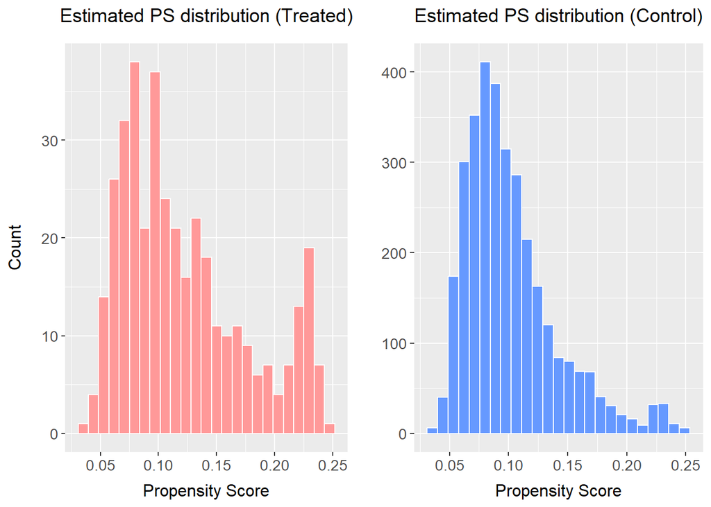

```r
options(repr.plot.width = 15, repr.plot.height = 7.5)
plt1 <- ggplot() +
  geom_histogram(data = data.frame(ps = ps.model$fitted.values[TrustVic$x_threat == 1]),
                 bins = 25, aes(x = ps), fill='#FF9999', color="white")+
  labs(title = 'Estimated PS distribution (Treated)', x = 'Propensity Score', y = 'Count') +
  theme(plot.title = element_text(size=13.5, hjust=0.5, margin=unit(c(0,0,.45,0), 'cm')),
        axis.title.x = element_text(size=12, margin=unit(c(.25,0,0,0), 'cm')),
        axis.title.y = element_text(size=12, margin=unit(c(0,.45,0,0), 'cm')),
        axis.text = element_text(size=10.5))
plt2 <- ggplot() +
  geom_histogram(data = data.frame(ps = ps.model$fitted.values[TrustVic$x_threat == 0]),
                 bins = 25, aes(x = ps), fill='#6699FF', color="white")+
  labs(title = 'Estimated PS distribution (Control)', x = 'Propensity Score', y = '') +
  theme(plot.title = element_text(size=13.5, hjust=0.5, margin=unit(c(0,0,.45,0), 'cm')),
        axis.title.x = element_text(size=12, margin=unit(c(.25,0,0,0), 'cm')),
        axis.text = element_text(size=10.5))
grid.newpage()
pushViewport(viewport(layout = grid.layout(1, 2)))
print(plt1, vp=viewport(layout.pos.row=1, layout.pos.col=1))
print(plt2, vp=viewport(layout.pos.row=1, layout.pos.col=2))
```

The estimated propensity scores of both treated and control groups fall in the interval [0,0.26], which is their common support. The overlap is satisfactory in terms of positivity assumption.

## Matching

We have noticed that in our data, the size of treated group is far smaller than the control group. So we applied propensity score matching to our data. In our study, we use one-to-one matching without replacement, so that each treated unit is matched with one control unit. We choose the linear propensity score $e(C)$ as the distance metric, i.e.
$$D_{ij} = \left\vert \log \frac{e(C_i)}{1-e(C_i)}
- \log \frac{e(C_j)}{1-e(C_j)}\right\vert,$$
and we match each treated unit with its nearest neighbor in control group. This method is not guaranteed to be optimal since the order of matching can affect our result. Also note that after matching, our estimand is the average treatment effect for the treated group (ATT) instead of average treatment effect (ATE).

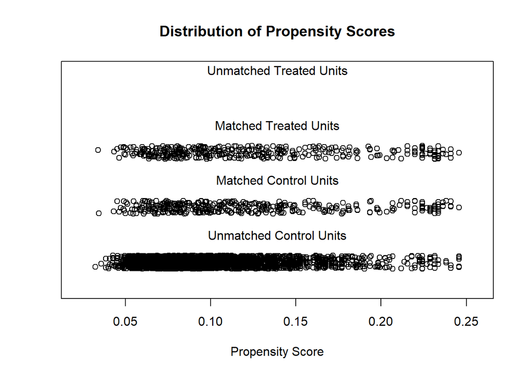

```
## To identify the units, use first mouse button; to stop, use second.
```

```r
match.model <- matchit(x_threat ~ c_age + c_male + c_education + c_income,
                  method = 'nearest', data=TrustVic, distance = 'glm',
                  ratio=1, replace=FALSE)
TrustVicMatched <- match.data(match.model)
# Draw a jitter plot.
plot(match.model, type='jitter')
```

After matching, we need to check the covariate balance between treatment and control groups to verify the exchangeability. To check this, we plot the mean of each covariate against the estimated propensity score, separately by treatment status. In a good matching result, the treatment and control groups should have nearly identical means of each covariate at each level of the propensity score. Here we use a lowess smoother to estimate the mean of each covariate, by treatment status, at each level of the propensity score.

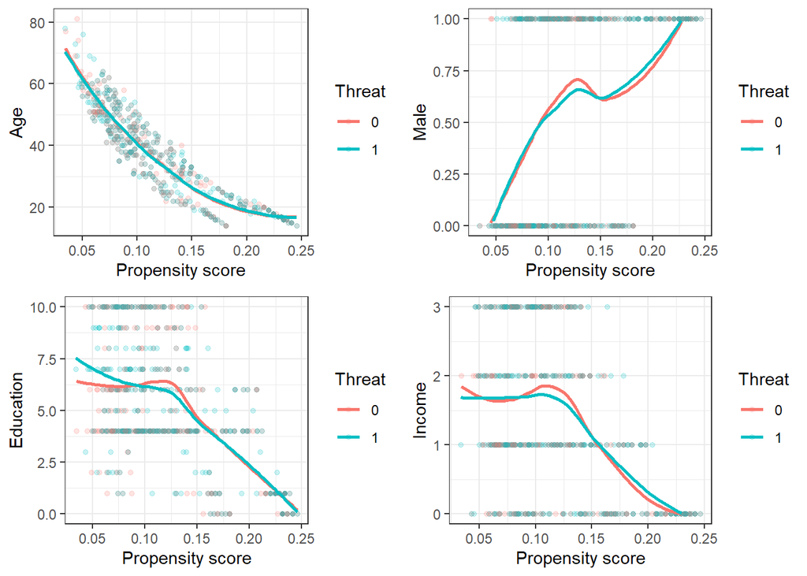

```r
plotLowess <- function(data, variable, ylabel) {
  data$variable <- data[, variable]
  data$x_threat <- as.factor(data$x_threat)
  support <- c(min(data$variable), max(data$variable))
  ggplot(data, aes(x = distance, y = variable, color = x_threat)) +
    geom_point(alpha = 0.2, size = 1.2) +
    geom_smooth(method = "loess", se = F) +
    labs(x = "Propensity score", y = ylabel, col = 'Threat') +
    theme_bw() +
    ylim(support)
}

grid.newpage()
pushViewport(viewport(layout = grid.layout(2, 2)))
print(plotLowess(TrustVicMatched, 'c_age', 'Age'),
      vp=viewport(layout.pos.row=1, layout.pos.col=1))
print(plotLowess(TrustVicMatched, 'c_male', 'Male'),
      vp=viewport(layout.pos.row=1, layout.pos.col=2))
print(plotLowess(TrustVicMatched, 'c_education', 'Education'),
      vp=viewport(layout.pos.row=2, layout.pos.col=1))
print(plotLowess(TrustVicMatched, 'c_income', 'Income'),
      vp=viewport(layout.pos.row=2, layout.pos.col=2))
```

As is shown in the plot, the treatment and control groups have nearly identical means of each covariate at each level of the propensity score, indicating that all covariates are balanced well within our matched groups. Furthermore, we compute the standardized difference-in-means by treatment status to check the covariate balance over the entire groups.

```r
table1 <- CreateTableOne(var=c('c_age', 'c_male', 'c_education', 'c_income'),
                         strata='x_threat', data=TrustVic, test = TRUE)
table2 <- CreateTableOne(var=c('c_age', 'c_male', 'c_education', 'c_income'),
                         strata='x_threat', data=TrustVicMatched, test=TRUE)
kableone(table1, smd=TRUE)  # Before Matching.
```

|  | 0 | 1 | p | test | SMD |
| --- | --- | --- | --- | --- | --- |
| n | 3271 | 379 |  |  |  |
| c_age (mean (SD)) | 42.38 (13.09) | 37.23 (14.26) | <0.001 |  | 0.376 |
| c_male (mean (SD)) | 0.47 (0.50) | 0.55 (0.50) | 0.004 |  | 0.155 |
| c_education (mean (SD)) | 5.60 (2.88) | 5.15 (3.02) | 0.004 |  | 0.152 |
| c_income (mean (SD)) | 1.45 (1.14) | 1.30 (1.14) | 0.016 |  | 0.131 |

```r
kableone(table2, smd=TRUE)  # After Matching.
```

|  | 0 | 1 | p | test | SMD |
| --- | --- | --- | --- | --- | --- |
| n | 379 | 379 |  |  |  |
| c_age (mean (SD)) | 37.23 (14.27) | 37.23 (14.26) | 0.996 |  | <0.001 |
| c_male (mean (SD)) | 0.55 (0.50) | 0.55 (0.50) | 1.000 |  | <0.001 |
| c_education (mean (SD)) | 5.12 (3.12) | 5.15 (3.02) | 0.915 |  | 0.008 |
| c_income (mean (SD)) | 1.31 (1.15) | 1.30 (1.14) | 0.924 |  | 0.007 |

It is seen that, before matching, the SMDs of all covariates are greater than 0.1, indicating an imbalance between two groups. After matching, all SMDs are reduced to less than 0.01. Hence, the matching result achieves a good balance between the treatment and the control groups.

After checking the covariate balance, we apply a paired t-test to the matched units to estimate the ATT and its uncertainty, as well as a two-sample (unpaired) $t$-test for comparison. The result is shown below.

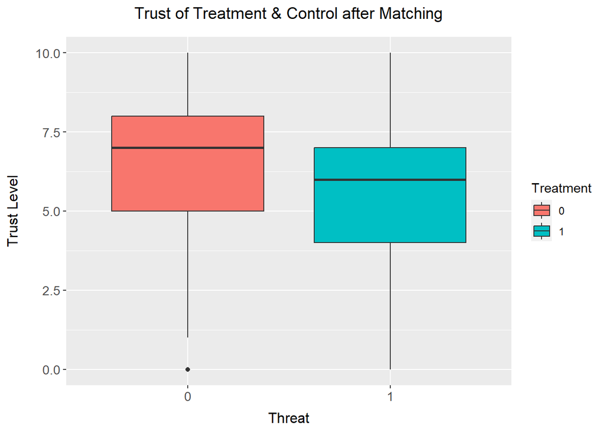

```r
ggplot(TrustVicMatched) +
  geom_boxplot(aes(y = y_trust, x = as.factor(x_threat),
                   group = as.factor(x_threat), fill = as.factor(x_threat)),) +
  labs(title = 'Trust of Treatment & Control after Matching', x = 'Threat',
       y = 'Trust Level', fill = 'Treatment') +
  theme(plot.title = element_text(size=13.5, hjust=0.5, margin=unit(c(0,0,.45,0), 'cm')),
        axis.title.x = element_text(size=12, margin=unit(c(.25,0,0,0), 'cm')),
        axis.title.y = element_text(size=12, margin=unit(c(0,.45,0,0), 'cm')),
        axis.text = element_text(size=10.5))
```

```r
outcomeT <- with(arrange(TrustVicMatched, subclass), y_trust[x_threat == 1])
outcomeC <- with(arrange(TrustVicMatched, subclass), y_trust[x_threat == 0])
with(TrustVicMatched, t.test(outcomeT, outcomeC, paired = TRUE))
```

```
##
##  Paired t-test
##
## data:  outcomeT and outcomeC
## t = -5.2239, df = 378, p-value = 2.902e-07
## alternative hypothesis: true difference in means is not equal to 0
## 95 percent confidence interval:
##  -1.0967612 -0.4969063
## sample estimates:
## mean of the differences
##              -0.7968338
```

```r
with(TrustVicMatched, t.test(outcomeT, outcomeC, var.equal = TRUE, paired = FALSE))
```

```
##
##  Two Sample t-test
##
## data:  outcomeT and outcomeC
## t = -4.8422, df = 756, p-value = 1.558e-06
## alternative hypothesis: true difference in means is not equal to 0
## 95 percent confidence interval:
##  -1.1198851 -0.4737824
## sample estimates:
## mean of x mean of y
##  5.591029  6.387863
```

In the previous analysis, we only include the propensity score in our distance measure. Such matching method can lead to inexact match and systematic bias. To avoid this problem, we adopt a doubly-robust approach. We fit a regression model to our sample with adjustment for confoundings, in our problem, the age, gender, education and income. The result is shown below.

```r
match.lr <- lm(y_trust ~ c_age + c_male + c_education + c_income + x_threat,
           data=TrustVicMatched)
summary(match.lr)
```

```
##
## Call:
## lm(formula = y_trust ~ c_age + c_male + c_education + c_income +
##     x_threat, data = TrustVicMatched)
##
## Residuals:
##     Min      1Q  Median      3Q     Max
## -6.8229 -1.2212  0.2562  1.5293  5.3284
##
## Coefficients:
##              Estimate Std. Error t value Pr(>|t|)
## (Intercept)  5.613529   0.283733  19.785  < 2e-16 ***
## c_age        0.007871   0.007022   1.121 0.262724
## c_male      -0.411006   0.178663  -2.300 0.021696 *
## c_education  0.118651   0.033194   3.574 0.000373 ***
## c_income     0.075595   0.097319   0.777 0.437533
## x_threat    -0.799095   0.160489  -4.979 7.93e-07 ***
## ---
## Signif. codes:  0 '***' 0.001 '**' 0.01 '*' 0.05 '.' 0.1 ' ' 1
##
## Residual standard error: 2.209 on 752 degrees of freedom
## Multiple R-squared:  0.08244,    Adjusted R-squared:  0.07634
## F-statistic: 13.51 on 5 and 752 DF,  p-value: 1.218e-12
```

The result shows that the estimated average causal effect (the coefficient of `x_threat`) is -0.799. The estimators with and without adjustment do not diverge since the covariates are well-balanced in our matched units.

## Weighting

In the previous section, we have estimated the propensity scores of our sample units, hence we can apply inverse probability weighting (IPW) to both the treatment and control groups based on the estimated propensity score. The weight can be formulated as
$$w_i = \frac{1}{A_i\cdot e(C_i) + (1-A_i)\cdot
\left(1-e(C_i)\right)}.$$
We compute the IP weights of our samples, and draw a density plot for the weights.

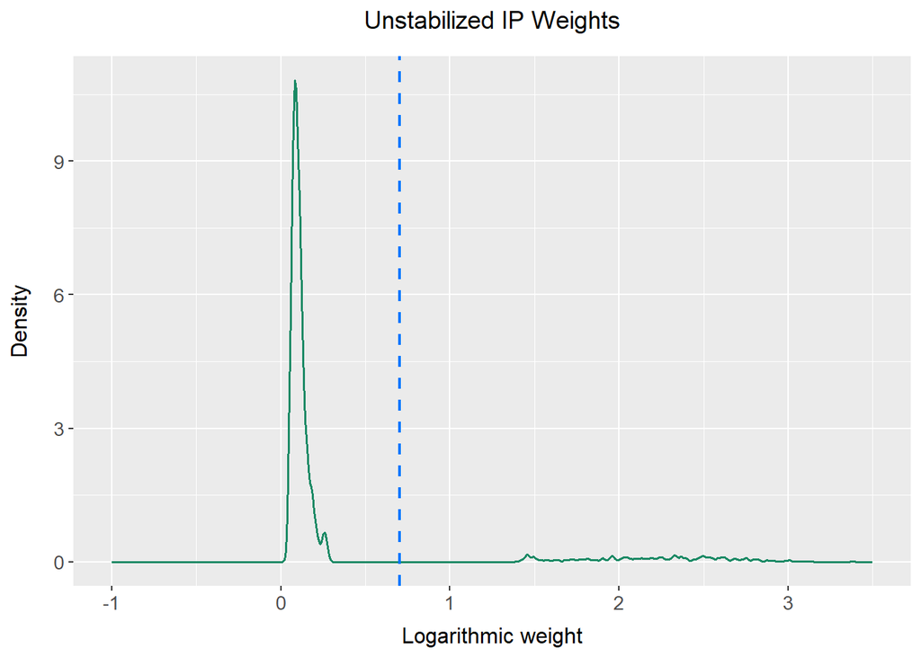

```r
# Unstabilized IP weighting.
ps <- ps.model$fitted.values
prob_t <- mean(TrustVic$x_threat)
ipw <- ifelse(TrustVic$x_threat == 1, 1 / ps, 1 / (1 - ps))

ggplot(data.frame(ipw = ipw)) +
  geom_density(aes(x = log(ipw), colour='density'), colour = '#198964', size = 0.65) +
  geom_vline(aes(xintercept=log(mean(ipw)), colour='Mean'),
            colour="#0077FF", linetype="dashed", size=0.85) +
  labs(title = 'Unstabilized IP Weights', x = 'Logarithmic weight', y = 'Density') +
  scale_x_continuous(limits = c(-1, 3.5)) +
  theme(plot.title = element_text(size=13.5, hjust=0.5, margin=unit(c(0,0,.45,0), 'cm')),
        axis.title.x = element_text(size=12, margin=unit(c(.25,0,0,0), 'cm')),
        axis.title.y = element_text(size=12, margin=unit(c(0,.45,0,0), 'cm')),
        axis.text = element_text(size=10.5))
```

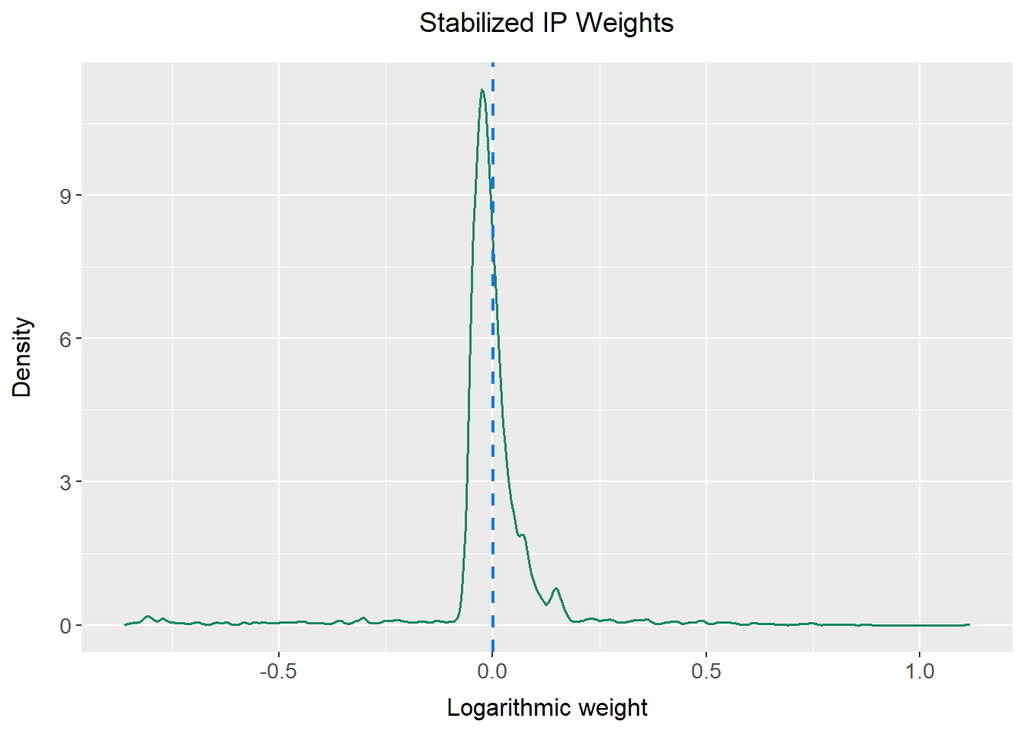

```r
# Stabilized IP weighting.
ipw <- ifelse(TrustVic$x_threat == 1, prob_t / ps, (1 - prob_t) / (1 - ps))
TrustVicWeighted <- cbind(TrustVic, ipw)

options(repr.plot.width = 5, repr.plot.height = 5)
ggplot(TrustVicWeighted) +
  geom_density(aes(x = log(ipw)), color = '#198964', size = 0.65) +
  geom_vline(aes(xintercept=log(mean(ipw))),
            color="#0077FF", linetype="dashed", size=0.85) +
  labs(title = 'Stabilized IP Weights', x = 'Logarithmic weight', y = 'Density') +
  theme(plot.title = element_text(size=13.5, hjust=0.5, margin=unit(c(0,0,.45,0), 'cm')),
        axis.title.x = element_text(size=12, margin=unit(c(.25,0,0,0), 'cm')),
        axis.title.y = element_text(size=12, margin=unit(c(0,.45,0,0), 'cm')),
        axis.text = element_text(size=10.5))
```

It is seen that, after stabilization, the weights of our samples have smaller variance, which helps to reduce uncertainty and improve the robustness of our post-weighting analysis. Let’s check the SMD between treatment and control groups before and after matching.

```r
iptwsvy <- svydesign(ids = ~ 1, data = TrustVicWeighted, weights = ~ ipw)
table3 <- svyCreateTableOne(var=c('c_age', 'c_male', 'c_education', 'c_income'),
                         strata='x_threat', data=iptwsvy, test=TRUE)
kableone(table1, smd=TRUE)  # Before IPW.
```

|  | 0 | 1 | p | test | SMD |
| --- | --- | --- | --- | --- | --- |
| n | 3271 | 379 |  |  |  |
| c_age (mean (SD)) | 42.38 (13.09) | 37.23 (14.26) | <0.001 |  | 0.376 |
| c_male (mean (SD)) | 0.47 (0.50) | 0.55 (0.50) | 0.004 |  | 0.155 |
| c_education (mean (SD)) | 5.60 (2.88) | 5.15 (3.02) | 0.004 |  | 0.152 |
| c_income (mean (SD)) | 1.45 (1.14) | 1.30 (1.14) | 0.016 |  | 0.131 |

```r
kableone(table3, smd=TRUE)  # After IPW.
```

|  | 0 | 1 | p | test | SMD |
| --- | --- | --- | --- | --- | --- |
| n | 3269.85 | 387.29 |  |  |  |
| c_age (mean (SD)) | 41.87 (13.22) | 42.77 (13.92) | 0.268 |  | 0.066 |
| c_male (mean (SD)) | 0.48 (0.50) | 0.45 (0.50) | 0.312 |  | 0.058 |
| c_education (mean (SD)) | 5.55 (2.90) | 5.78 (2.87) | 0.161 |  | 0.079 |
| c_income (mean (SD)) | 1.44 (1.14) | 1.48 (1.12) | 0.448 |  | 0.043 |

As is shown above, the SMDs of all covariates were reduced to less than 0.1 after IP weighting, indicating a good balance in our weighted pseudo-population. We assume a marginal structural model in our problem:
$$\mathbb{E}[Y^a] = \beta_0 + \beta_1
a,$$
in which $\beta_1 = \mathbb{E}[Y^1 - Y^0]$ is the average causal effect. For estimation, we fit a weighted regression model $\mathbb{E}[Y|A] = \theta_0 + \theta_1 A$ to our pseudo-population. Under the assumption of no unmeasured confounding, the weighted regression estimates the parameters of the MSM with consistency. Our result is shown below.

```r
# Marginal Structural Model.
weighted.lr <- lm(y_trust ~ x_threat, data = TrustVicWeighted, weights = ipw)
summary(weighted.lr)
```

```
##
## Call:
## lm(formula = y_trust ~ x_threat, data = TrustVicWeighted, weights = ipw)
##
## Weighted Residuals:
##     Min      1Q  Median      3Q     Max
## -7.5232 -1.3853  0.5875  1.5766  5.3568
##
## Coefficients:
##             Estimate Std. Error t value Pr(>|t|)
## (Intercept)  6.40150    0.03697 173.160  < 2e-16 ***
## x_threat    -0.61956    0.11360  -5.454 5.26e-08 ***
## ---
## Signif. codes:  0 '***' 0.001 '**' 0.01 '*' 0.05 '.' 0.1 ' ' 1
##
## Residual standard error: 2.114 on 3648 degrees of freedom
## Multiple R-squared:  0.008087,   Adjusted R-squared:  0.007815
## F-statistic: 29.74 on 1 and 3648 DF,  p-value: 5.26e-08
```

The average causal effect estimated by IP-weighted regression is -0.620, with $p$-value less than 0.001, hence the result is very significant. If all individuals had been in threat, their generalized trust would drop by -0.620 in average. Also, an approximate 95% confidence interval is given by $[-0.842, -0.397]$.

## Summary

In this study, we have investigated the causal effect of victimization on trust. We applied different method to analyze our data, including regression with and without potential confounders, propensity score matching and IP weighting. All these methods gave an significant effect of victimization, and the estimated causal effect did not vary a lot across them. (Note that, in propensity score matching, our estimand changes from ATE to ATT, which is constrained in the treatment group.) Hence, the result of our study is robust.